# Introduction to Computer Vision: Plant Seedlings Classification

## Problem Statement

### Context

In recent times, the field of agriculture has been in urgent need of modernizing, since the amount of manual work people need to put in to check if plants are growing correctly is still highly extensive. Despite several advances in agricultural technology, people working in the agricultural industry still need to have the ability to sort and recognize different plants and weeds, which takes a lot of time and effort in the long term. The potential is ripe for this trillion-dollar industry to be greatly impacted by technological innovations that cut down on the requirement for manual labor, and this is where Artificial Intelligence can actually benefit the workers in this field, as **the time and energy required to identify plant seedlings will be greatly shortened by the use of AI and Deep Learning.** The ability to do so far more efficiently and even more effectively than experienced manual labor, could lead to better crop yields, the freeing up of human inolvement for higher-order agricultural decision making, and in the long term will result in more sustainable environmental practices in agriculture as well.

### Objective

The aim of this project is to Build a Convolutional Neural Netowrk to classify plant seedlings into their respective categories.

### Data Dictionary

The Aarhus University Signal Processing group, in collaboration with the University of Southern Denmark, has recently released a dataset containing **images of unique plants belonging to 12 different species.**

- The dataset can be download from Olympus.
- The data file names are:
  - images.npy
  - Labels.csv
- Due to the large volume of data, the images were converted to the images.npy file and the labels are also put into Labels.csv, so that you can work on the data/project seamlessly without having to worry about the high data volume.
- The goal of the project is to create a classifier capable of determining a plant's species from an image.

**List of Species**

- Black-grass
- Charlock
- Cleavers
- Common Chickweed
- Common Wheat
- Fat Hen
- Loose Silky-bent
- Maize
- Scentless Mayweed
- Shepherds Purse
- Small-flowered Cranesbill
- Sugar beet

### **Note: Please use GPU runtime on Google Colab to execute the code faster.**

## Importing necessary libraries

```python
# Installing the libraries with the specified version.
# uncomment and run the following line if Google Colab is being used
#!pip install tensorflow==2.15.0 scikit-learn==1.2.2 seaborn==0.13.1 matplotlib==3.7.1 numpy==1.25.2 pandas==1.5.3 opencv-python==4.8.0.76 -q --user
```

```python
# Installing the libraries with the specified version.
# uncomment and run the following lines if Jupyter Notebook is being used
#!pip install tensorflow==2.13.0 scikit-learn==1.2.2 seaborn==0.11.1 matplotlib==3.3.4 numpy==1.24.3 pandas==1.5.2 opencv-python==4.8.0.76 -q --user
```

**Note**: *After running the above cell, kindly restart the notebook kernel and run all cells sequentially from the start again.*

```python
import os
import numpy as np                                                                               # Importing numpy for Matrix Operations
import pandas as pd                                                                              # Importing pandas to read CSV files
import matplotlib.pyplot as plt                                                                  # Importting matplotlib for Plotting and visualizing images
import math                                                                                      # Importing math module to perform mathematical operations
import cv2                                                                                       # Importing openCV for image processing
import seaborn as sns                                                                            # Importing seaborn to plot graphs


# Tensorflow modules
import tensorflow as tf
from tensorflow.keras.preprocessing.image import ImageDataGenerator                              # Importing the ImageDataGenerator for data augmentation
from tensorflow.keras.models import Sequential                                                   # Importing the sequential module to define a sequential model
from tensorflow.keras.layers import Dense,Dropout,Flatten,Conv2D,MaxPooling2D,BatchNormalization # Defining all the layers to build our CNN Model
from tensorflow.keras.optimizers import Adam,SGD                                                 # Importing the optimizers which can be used in our model
from sklearn import preprocessing                                                                # Importing the preprocessing module to preprocess the data
from sklearn.model_selection import train_test_split                                             # Importing train_test_split function to split the data into train and test
from sklearn.metrics import confusion_matrix                                                     # Importing confusion_matrix to plot the confusion matrix

# Display images using OpenCV
from google.colab.patches import cv2_imshow                                                      # Importing cv2_imshow from google.patches to display images

# Ignore warnings
import warnings
warnings.filterwarnings('ignore')
```

## Loading the dataset

```python
# Uncomment and run the below code if you are using google colab
from google.colab import drive
drive.mount('/content/drive')
```

```python
# Load the image file of the dataset
images = np.load('/content/drive/MyDrive/images.npy')

# Load the labels file of the dataset
labels = pd.read_csv('/content/drive/MyDrive/Labels.csv')
```

## Data Overview

### Understand the shape of the dataset

```python
print(images.shape)
print(labels.shape)
```

```
(4750, 128, 128, 3)
(4750, 1)
```

There are 4750 RGB images of shape 128 x 128 X 3, each image having 3 channels.

## Exploratory Data Analysis

- EDA is an important part of any project involving data.
- It is important to investigate and understand the data better before building a model with it.
- A few questions have been mentioned below which will help you understand the data better.
- A thorough analysis of the data, in addition to the questions mentioned below, should be done.
1. How are these different category plant images different from each other?
2. Is the dataset provided an imbalance? (Check with using bar plots)

```python
# Common reusable functions
def plot_images(images,labels):
  num_classes=12                                                                 # Number of Classes
  categories=np.unique(labels)
  keys=dict(labels['Label'])                                                      # Obtaing the unique classes from y_train
  rows = 3                                                                        # Defining number of rows=3
  cols = 4                                                                        # Defining number of columns=4
  fig = plt.figure(figsize=(10, 8))                                               # Defining the figure size to 10x8
  for i in range(cols):
      for j in range(rows):
          random_index = np.random.randint(0, len(labels))                        # Generating random indices from the data and plotting the images
          ax = fig.add_subplot(rows, cols, i * rows + j + 1)                      # Adding subplots with 3 rows and 4 columns
          ax.imshow(images[random_index, :])                                      # Plotting the image
          ax.set_title(keys[random_index])
  plt.show()
```

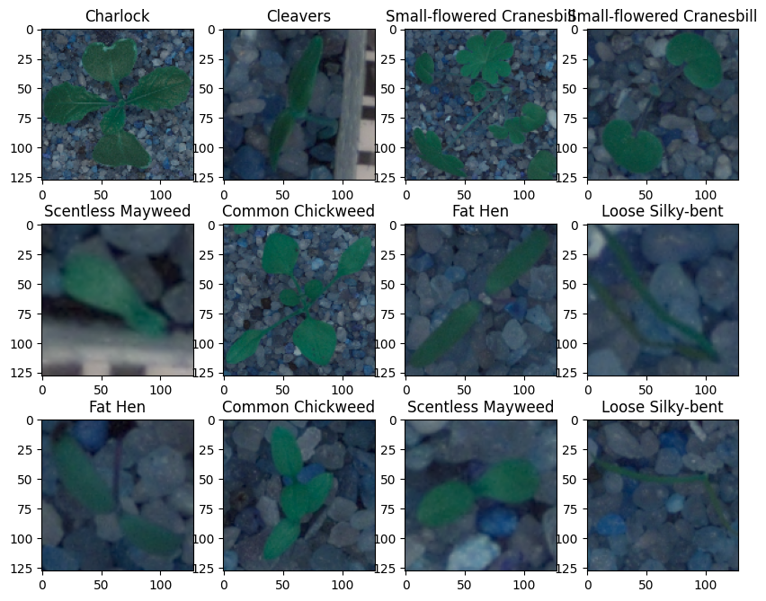

```python
plot_images(images,labels)
```

Some of them are zoomed in, some are not, some are rotated / tilted, some show edge and some show top view.

Data Augmentation can make CNNs recognize an object as an object, even when its appearance varies translationally in some way. Taking this property into consideration, we can augment the images later using some of the following techniques:

**1. Horizontal Flip** (should be set to True/False)  
**2. Vertical Flip** (should be set to True/False)  
**3. Height Shift** (should be between 0 and 1)  
**4. Width Shift** (should be between 0 and 1)  
**5. Rotation** (should be between 0 and 180)  
**6. Shear** (should be between 0 and 1)  
**7. Zoom** (should be between 0 and 1) etc.

## Checking for data imbalance

[output not shown]

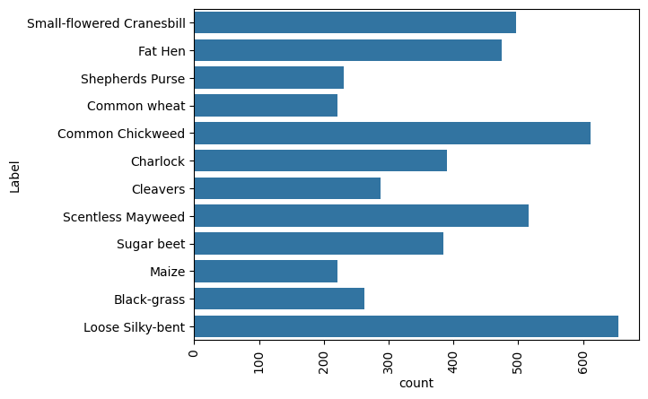

```python
 sns.countplot(labels['Label'])
 plt.xticks(rotation='vertical')
```

### Dataset is imbalanced. We will handle this later.

## Data Pre-Processing

### Convert the BGR images to RGB images.

```python
 ### randomly check out some of the images and see what they look like:
cv2_imshow(images[5])
```

[figure not shown]

```python
plt.imshow(images[5])
```

- We can observe that the images are being shown in different colors when plotted with openCV and matplotlib as OpenCV reads images in BGR format and this shows that the given numpy arrays were generated from the original images using OpenCV.
- Now we will convert these BGR images to RGB images so we could interpret them easily.

```python
# Converting the images from BGR to RGB using cvtColor function of OpenCV
for i in range(len(images)):
  images[i] = cv2.cvtColor(images[i], cv2.COLOR_BGR2RGB)
```

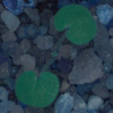

```python
cv2_imshow(images[5])
```

### Resize the images

As the size of the images is large, it may be computationally expensive to train on these larger images; therefore, it is preferable to reduce the image size from 128 to 64.

```python
images_decreased=[]
height = 64
width = 64
dimensions = (width, height)
for i in range(len(images)):
  images_decreased.append( cv2.resize(images[i], dimensions, interpolation=cv2.INTER_LINEAR))
```

```python
plt.imshow(images_decreased[3])
```

[output not shown]

```python
# Applying Gaussian Blur to denoise the images
images_gb=[]
for i in range(len(images)):
  # gb[i] = cv2.cvtColor(images[i], cv2.COLOR_BGR2RGB)
  images_gb.append(cv2.GaussianBlur(images[i], ksize =(3,3),sigmaX =  0))
```

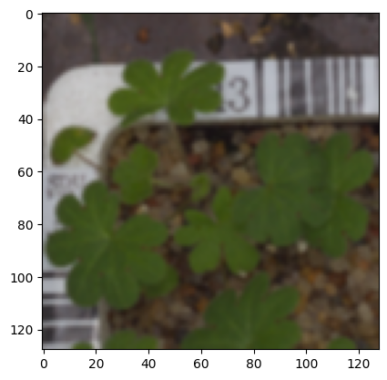

```python
plt.imshow(images_gb[3])
```

### Data Preparation for Modeling

- Before you proceed to build a model, you need to split the data into train, test, and validation to be able to evaluate the model that you build on the train data
- You'll have to encode categorical features and scale the pixel values.
- You will build a model using the train data and then check its performance

**Split the dataset**

```python
from sklearn.model_selection import train_test_split
#  use 10% of our data for testing, 10% of our data for validation and 80% of our data for training.
X_temp, X_test, y_temp, y_test = train_test_split(np.array(images_decreased),labels , test_size=0.1, random_state=42,stratify=labels)
X_train, X_val, y_train, y_val = train_test_split(X_temp,y_temp , test_size=0.1, random_state=42,stratify=y_temp)
```

```python
print(X_train.shape,y_train.shape)
print(X_val.shape,y_val.shape)
print(X_test.shape,y_test.shape)
```

```
(3847, 64, 64, 3) (3847, 1)
(428, 64, 64, 3) (428, 1)
(475, 64, 64, 3) (475, 1)
```

```python
#The below code can be used to treat the class imbalance by increasing the weights of the minority classes.
from sklearn.utils import class_weight

labelList = labels.Label.unique()
class_weights = class_weight.compute_class_weight(class_weight = "balanced",
                                                  classes = np.array(labelList),
                                                  y = y_train.values.reshape(-1)
                                                  )
class_weights = dict(zip(np.array(range(len(labelList))), class_weights))
#print calculated class weights
class_weights

# use this in fit()
```

```
{0: 0.7974709784411277,
 1: 0.8348524305555556,
 2: 1.714349376114082,
 3: 1.7909683426443204,
 4: 0.6476430976430977,
 5: 1.0145042194092826,
 6: 1.3818247126436782,
 7: 0.7669457735247209,
 8: 1.0275106837606838,
 9: 1.7909683426443204,
 10: 1.5050860719874803,
 11: 0.604874213836478}
```

### Encode the target labels

```python
# Convert labels from names to one hot vectors.
# We have already used encoding methods like onehotencoder and labelencoder earlier so now we will be using a new encoding method called labelBinarizer.
# Labelbinarizer works similar to onehotencoder

from sklearn.preprocessing import LabelBinarizer
enc = LabelBinarizer()
y_train_encoded = enc.fit_transform(y_train)
y_val_encoded=enc.transform(y_val)
y_test_encoded=enc.transform(y_test)
```

### Data Normalization

```python
# Normalizing the image pixels
X_train_normalized = X_train.astype('float32')/255.0
X_val_normalized = X_val.astype('float32')/255.0
X_test_normalized = X_test.astype('float32')/255.0

train_datagen = ImageDataGenerator()
test_datagen  = ImageDataGenerator()
val_datagen  = ImageDataGenerator()

batch_size=64

train_generator = train_datagen.flow(X_train_normalized, y_train_encoded,
                                       batch_size=batch_size,
                                       seed=42,
                                       shuffle=True)

# Flowing testing images in batches of 20 using test_datagen generator
validation_generator =  val_datagen.flow(X_val_normalized, y_val_encoded,
                                          batch_size=batch_size,
                                          seed=42,
                                          shuffle=True)

test_generator =  test_datagen.flow(X_test_normalized, y_test_encoded,
                                    batch_size=batch_size,
                                    seed=42,
                                    shuffle=True)
```

## Model Building

```python
# Clearing backend
from tensorflow.keras import backend
backend.clear_session()
```

```python
# Fixing the seed for random number generators
import random
np.random.seed(42)
random.seed(42)
tf.random.set_seed(42)
```

```python
# Intializing a sequential model
model = Sequential()

# Adding first conv layer with 64 filters and kernel size 3x3 , padding 'same' provides the output size same as the input size
# Input_shape denotes input image dimension of images
model.add(Conv2D(64, (3, 3), activation='relu', padding="same", input_shape=(64, 64, 3)))

# Adding max pooling to reduce the size of output of first conv layer
model.add(MaxPooling2D((2, 2), padding = 'same'))

model.add(Conv2D(32, (3, 3), activation='relu', padding="same"))
model.add(MaxPooling2D((2, 2), padding = 'same'))
model.add(Conv2D(32, (3, 3), activation='relu', padding="same"))
model.add(MaxPooling2D((2, 2), padding = 'same'))
# flattening the output of the conv layer after max pooling to make it ready for creating dense connections
model.add(Flatten())

# Adding a fully connected dense layer with 100 neurons
model.add(Dense(16, activation='relu'))
model.add(Dropout(0.3))
# Adding the output layer with 12 neurons and activation functions as softmax since this is a multi-class classification problem
model.add(Dense(12, activation='softmax'))

# Using SGD Optimizer
# opt = SGD(learning_rate=0.01, momentum=0.9)
opt=Adam()
# Compile model
model.compile(optimizer=opt, loss='categorical_crossentropy', metrics=['accuracy'])

# Generating the summary of the model
model.summary()
```

```
Model: "sequential"
_________________________________________________________________
 Layer (type)                Output Shape              Param #
=================================================================
 conv2d (Conv2D)             (None, 64, 64, 64)        1792

 max_pooling2d (MaxPooling2  (None, 32, 32, 64)        0
 D)

 conv2d_1 (Conv2D)           (None, 32, 32, 32)        18464

 max_pooling2d_1 (MaxPoolin  (None, 16, 16, 32)        0
 g2D)

 conv2d_2 (Conv2D)           (None, 16, 16, 32)        9248

 max_pooling2d_2 (MaxPoolin  (None, 8, 8, 32)          0
 g2D)

 flatten (Flatten)           (None, 2048)              0

 dense (Dense)               (None, 16)                32784

 dropout (Dropout)           (None, 16)                0

 dense_1 (Dense)             (None, 12)                204

=================================================================
Total params: 62492 (244.11 KB)
Trainable params: 62492 (244.11 KB)
Non-trainable params: 0 (0.00 Byte)
_________________________________________________________________
```

Model 1 has 62492 trainable parameters

```python
#Fitting model on train data
# Pulling a single large batch of random testing data for testing after each epoch
# Note: use y_val_encode and valX
epoch = 30
batch_size = 64
history_1 = model.fit(train_generator, validation_data=validation_generator,
                      # Hyperparams below
                      epochs=epoch, batch_size=batch_size, class_weight=class_weights,
                      verbose=2)
```

```
61/61 - 5s - loss: 2.9374 - accuracy: 0.1118 - val_loss: 2.4376 - val_accuracy: 0.1285 - 5s/epoch - 79ms/step
61/61 - 0s - loss: 2.7245 - accuracy: 0.1929 - val_loss: 2.1833 - val_accuracy: 0.3224 - 435ms/epoch - 7ms/step
61/61 - 0s - loss: 2.4126 - accuracy: 0.2865 - val_loss: 1.9823 - val_accuracy: 0.3505 - 417ms/epoch - 7ms/step
61/61 - 0s - loss: 2.2272 - accuracy: 0.3382 - val_loss: 1.8759 - val_accuracy: 0.3692 - 411ms/epoch - 7ms/step
61/61 - 0s - loss: 2.0633 - accuracy: 0.3702 - val_loss: 1.7237 - val_accuracy: 0.4322 - 436ms/epoch - 7ms/step
61/61 - 0s - loss: 1.9452 - accuracy: 0.3798 - val_loss: 1.7507 - val_accuracy: 0.4369 - 438ms/epoch - 7ms/step
61/61 - 0s - loss: 1.8558 - accuracy: 0.4045 - val_loss: 1.5218 - val_accuracy: 0.4813 - 439ms/epoch - 7ms/step
61/61 - 0s - loss: 1.7720 - accuracy: 0.4110 - val_loss: 1.4652 - val_accuracy: 0.4766 - 426ms/epoch - 7ms/step
61/61 - 0s - loss: 1.7337 - accuracy: 0.4125 - val_loss: 1.4529 - val_accuracy: 0.5070 - 406ms/epoch - 7ms/step
61/61 - 0s - loss: 1.6524 - accuracy: 0.4403 - val_loss: 1.3740 - val_accuracy: 0.5537 - 412ms/epoch - 7ms/step
61/61 - 0s - loss: 1.6322 - accuracy: 0.4359 - val_loss: 1.3088 - val_accuracy: 0.5421 - 411ms/epoch - 7ms/step
61/61 - 0s - loss: 1.5808 - accuracy: 0.4611 - val_loss: 1.2550 - val_accuracy: 0.5654 - 443ms/epoch - 7ms/step
61/61 - 0s - loss: 1.5095 - accuracy: 0.4705 - val_loss: 1.2633 - val_accuracy: 0.5654 - 427ms/epoch - 7ms/step
61/61 - 0s - loss: 1.4834 - accuracy: 0.4835 - val_loss: 1.1803 - val_accuracy: 0.5888 - 443ms/epoch - 7ms/step
61/61 - 0s - loss: 1.5199 - accuracy: 0.4760 - val_loss: 1.1767 - val_accuracy: 0.5958 - 415ms/epoch - 7ms/step
61/61 - 0s - loss: 1.4297 - accuracy: 0.4983 - val_loss: 1.1775 - val_accuracy: 0.5841 - 440ms/epoch - 7ms/step
61/61 - 0s - loss: 1.3764 - accuracy: 0.5009 - val_loss: 1.1805 - val_accuracy: 0.5654 - 407ms/epoch - 7ms/step
61/61 - 0s - loss: 1.3884 - accuracy: 0.4955 - val_loss: 1.1184 - val_accuracy: 0.6075 - 407ms/epoch - 7ms/step
61/61 - 0s - loss: 1.3796 - accuracy: 0.4996 - val_loss: 1.1827 - val_accuracy: 0.5864 - 398ms/epoch - 7ms/step
61/61 - 0s - loss: 1.3468 - accuracy: 0.5058 - val_loss: 1.1471 - val_accuracy: 0.6332 - 377ms/epoch - 6ms/step
61/61 - 0s - loss: 1.3318 - accuracy: 0.5155 - val_loss: 1.1418 - val_accuracy: 0.6075 - 373ms/epoch - 6ms/step
61/61 - 0s - loss: 1.3436 - accuracy: 0.5181 - val_loss: 1.1065 - val_accuracy: 0.6168 - 365ms/epoch - 6ms/step
61/61 - 0s - loss: 1.2716 - accuracy: 0.5604 - val_loss: 1.1460 - val_accuracy: 0.6005 - 377ms/epoch - 6ms/step
61/61 - 0s - loss: 1.2708 - accuracy: 0.5477 - val_loss: 1.0899 - val_accuracy: 0.6075 - 390ms/epoch - 6ms/step
61/61 - 0s - loss: 1.2723 - accuracy: 0.5589 - val_loss: 1.0952 - val_accuracy: 0.6168 - 395ms/epoch - 6ms/step
61/61 - 0s - loss: 1.2762 - accuracy: 0.5508 - val_loss: 1.1212 - val_accuracy: 0.5935 - 375ms/epoch - 6ms/step
61/61 - 0s - loss: 1.2407 - accuracy: 0.5604 - val_loss: 1.1142 - val_accuracy: 0.6308 - 379ms/epoch - 6ms/step
61/61 - 0s - loss: 1.2527 - accuracy: 0.5646 - val_loss: 1.1288 - val_accuracy: 0.6215 - 391ms/epoch - 6ms/step
61/61 - 0s - loss: 1.2244 - accuracy: 0.5732 - val_loss: 1.0470 - val_accuracy: 0.6472 - 446ms/epoch - 7ms/step
61/61 - 0s - loss: 1.2064 - accuracy: 0.5693 - val_loss: 1.0716 - val_accuracy: 0.6425 - 407ms/epoch - 7ms/step
```

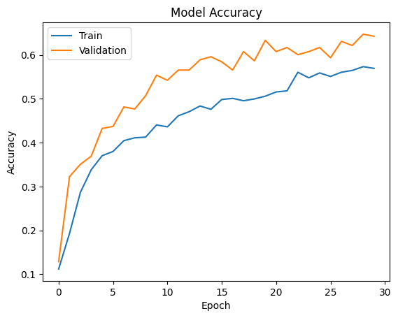

```python
#model evaluation
plt.plot(history_1.history['accuracy'])
plt.plot(history_1.history['val_accuracy'])
plt.title('Model Accuracy')
plt.ylabel('Accuracy')
plt.xlabel('Epoch')
plt.legend(['Train', 'Validation'], loc='upper left')
plt.show()
```

```python
#accuracy = model.evaluate(train_generator, verbose=2)
```

```python
# Evaluating on the Test dataset
accuracy = model.evaluate(test_generator, verbose=2)
```

```
8/8 - 0s - loss: 1.0787 - accuracy: 0.6505 - 145ms/epoch - 18ms/step
```

## Observations:

- Model 1 shows Test accuracy of 65%

```python
# Generate preditions using test data
y_pred=model.predict(test_generator, verbose = 1)
```

```python
y_pred
```

```
array([[4.28044533e-09, 7.84472292e-08, 4.41791563e-08, ...,
        4.68054757e-04, 1.74366249e-07, 5.44071570e-03],
       [4.02702298e-03, 2.09762398e-02, 8.56373161e-02, ...,
        1.09140195e-01, 1.14426546e-01, 2.31756747e-01],
       [3.14660902e-11, 2.19844892e-10, 2.16355384e-12, ...,
        1.76512953e-02, 2.87490920e-09, 2.12674149e-06],
       ...,
       [9.75503983e-11, 3.42778949e-05, 1.55068946e-07, ...,
        6.28330112e-01, 3.51957890e-04, 1.21889905e-04],
       [5.58077358e-02, 5.76627590e-02, 1.29785582e-01, ...,
        6.51597902e-02, 1.63785458e-01, 7.48722553e-02],
       [2.04832965e-17, 4.24199065e-10, 1.53775122e-14, ...,
        6.84257480e-04, 1.31466893e-10, 1.67248899e-07]], dtype=float32)
```

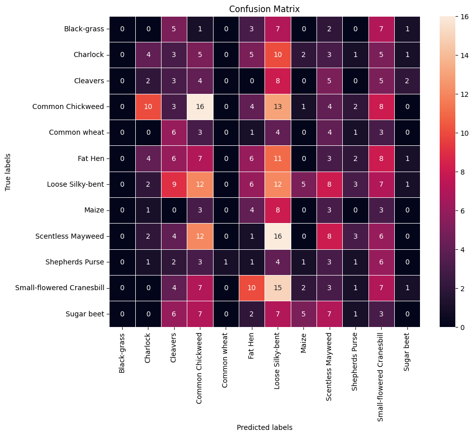

```python
# Obtaining the categorical values from y_test_encoded and y_pred
y_pred_arg=np.argmax(y_pred,axis=1)
####################
# Iterate over the test_generator to obtain the true labels
true_labels = []
for i in range(len(test_generator)):
    _, batch_true_labels = test_generator[i]
    true_labels.extend(batch_true_labels)

# Convert true_labels to a numpy array
y_test_encoded = np.array(true_labels)

#################

y_test_arg=np.argmax(y_test_encoded,axis=1)

# Plotting the Confusion Matrix using confusion matrix() function which is also predefined tensorflow module
confusion_matrix = tf.math.confusion_matrix(y_test_arg,y_pred_arg)
f, ax = plt.subplots(figsize=(10, 8))
sns.heatmap(
    confusion_matrix,
    annot=True,
    linewidths=.4,
    fmt="d",
    square=True,
    ax=ax,  xticklabels=enc.classes_, yticklabels=enc.classes_
)

plt.xlabel('Predicted labels')
plt.ylabel('True labels')
plt.title('Confusion Matrix')
plt.show()
```

## Observations:

```python
# Plotting the classification report
from sklearn import metrics

cr=metrics.classification_report(y_test_arg,y_pred_arg)     # Complete the code to plot the classification report
print(cr)
```

[output not shown]

## Model Performance Improvement

**Reducing the Learning Rate:**

**Hint**: Use **ReduceLRonPlateau()** function that will be used to decrease the learning rate by some factor, if the loss is not decreasing for some time. This may start decreasing the loss at a smaller learning rate. There is a possibility that the loss may still not decrease. This may lead to executing the learning rate reduction again in an attempt to achieve a lower loss.

### **Data Augmentation**

Remember, **data augmentation should not be used in the validation/test data set**.

```python
train_datagen2 = ImageDataGenerator(
                              horizontal_flip = True,
                              vertical_flip = True,
                              height_shift_range= 1,
                              width_shift_range=1,
                              rotation_range=180, fill_mode='nearest',
                              shear_range = 0.1, # 0.25
                              zoom_range=0.1
                              ) # 0.25

# Create data generators
# Flowing testing images in batches of 20 using respective generator
train_generator2 = train_datagen2.flow(X_train_normalized, y_train_encoded, batch_size=64)
```

Let's look at some examples of our augmented training data.

This is helpful for understanding the extent to which data is being manipulated prior to training, and can be compared with how the raw data looks prior to data augmentation.

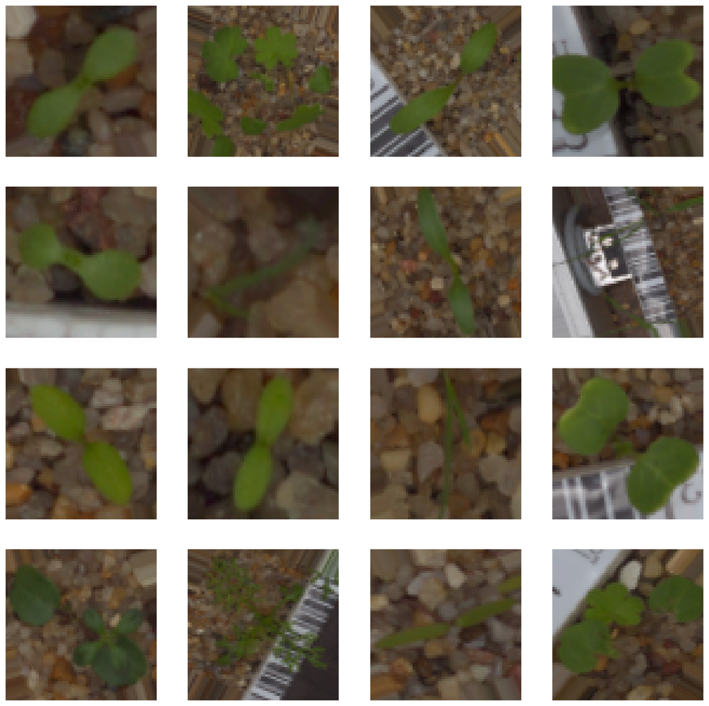

```python
images, labels = next(train_generator2)
fig, axes = plt.subplots(4, 4, figsize = (16, 8))
fig.set_size_inches(16, 16)
for (image, label, ax) in zip(images, labels, axes.flatten()):
    ax.imshow(image)
    ax.axis('off')
```

```python
#Clearing backend
from tensorflow.keras import backend
backend.clear_session()
```

```python
#Fixing the seed for random number generators
np.random.seed(42)
import random
random.seed(42)
tf.random.set_seed(42)
```

we will Batch Normalization and Dropout layers as regularization techniques to prevent overfitting.

```python
# Intializing a sequential model

from keras.layers import Activation

model_2 = Sequential()

#Group1
model_2.add(Conv2D(64, (3, 3), padding='same', input_shape=(64, 64, 3)))
model_2.add(Conv2D(64, (3, 3), padding='same', input_shape=(64, 64, 3)))
model_2.add(Conv2D(64, (3, 3), padding='same', input_shape=(64, 64, 3)))

model_2.add(BatchNormalization())
model_2.add(Activation('relu'))
model_2.add(MaxPooling2D((2, 2), padding='same'))
model_2.add(Dropout(0.25))

# Group 2
model_2.add(Conv2D(32, (3, 3), padding='same'))
model_2.add(Conv2D(32, (3, 3), padding='same'))
model_2.add(Conv2D(32, (3, 3), padding='same'))

model_2.add(Activation('relu'))
model_2.add(MaxPooling2D((2, 2), padding='same'))
model_2.add(Dropout(0.25))  # You can decide to use dropout here or not


# flattening the output of the conv layer after max pooling to make it ready for creating dense connections
model_2.add(Flatten())

# Adding a fully connected dense layer with 100 neurons
model_2.add(Dense(128, activation='relu'))
model_2.add(Dropout(0.25))
model_2.add(Dense(64, activation='relu'))

model_2.add(Dense(32, activation='relu'))


# Adding the output layer with 10 neurons and activation functions as softmax since this is a multi-class classification problem
model_2.add(Dense(12, activation='softmax'))

# Using Adam Optimizer
opt = Adam()

# Compile model
model_2.compile(optimizer=opt, loss='categorical_crossentropy', metrics=['accuracy'])
```

```python
model_2.summary()
```

```
Model: "sequential"
_________________________________________________________________
 Layer (type)                Output Shape              Param #
=================================================================
 conv2d (Conv2D)             (None, 64, 64, 64)        1792

 conv2d_1 (Conv2D)           (None, 64, 64, 64)        36928

 conv2d_2 (Conv2D)           (None, 64, 64, 64)        36928

 batch_normalization (Batch  (None, 64, 64, 64)        256
 Normalization)

 activation (Activation)     (None, 64, 64, 64)        0

 max_pooling2d (MaxPooling2  (None, 32, 32, 64)        0
 D)

 dropout (Dropout)           (None, 32, 32, 64)        0

 conv2d_3 (Conv2D)           (None, 32, 32, 32)        18464

 conv2d_4 (Conv2D)           (None, 32, 32, 32)        9248

 conv2d_5 (Conv2D)           (None, 32, 32, 32)        9248

 activation_1 (Activation)   (None, 32, 32, 32)        0

 max_pooling2d_1 (MaxPoolin  (None, 16, 16, 32)        0
 g2D)

 dropout_1 (Dropout)         (None, 16, 16, 32)        0

 flatten (Flatten)           (None, 8192)              0

 dense (Dense)               (None, 128)               1048704

 dropout_2 (Dropout)         (None, 128)               0

 dense_1 (Dense)             (None, 64)                8256

 dense_2 (Dense)             (None, 32)                2080

 dense_3 (Dense)             (None, 12)                396

=================================================================
Total params: 1172300 (4.47 MB)
Trainable params: 1172172 (4.47 MB)
Non-trainable params: 128 (512.00 Byte)
_________________________________________________________________
```

- Number of trainable params = 1172172

```python
from tensorflow.keras.callbacks import ReduceLROnPlateau
# use the ReduceLROnPlateau callback in TensorFlow/Keras, you need to set it up during the training of your model. This callback monitors a specified metric and reduces the learning rate when the monitored metric has stopped improving.

reduce_lr = ReduceLROnPlateau(monitor = 'val_loss',   #monitor='val_loss', val_accuracy  # Metric to monitor, e.g., validation loss
                              factor=0.1,           # Factor by which the learning rate will be reduced (new_lr = lr * factor)
                              patience=5,           # Number of epochs with no improvement after which learning rate will be reduced
                              min_lr=0.00001,        # Lower bound on the learning rate
                              verbose=1)            # Verbosity mode

# set it up during the training of your model
```

```python
# Epochs
epochs = 30
# Batch size
batch_size = 64

# Fitting the model
history_2 = model_2.fit(
                     train_generator2, validation_data=validation_generator,
                    epochs=epochs, batch_size = batch_size,
                    verbose=1, callbacks=[reduce_lr], class_weight=class_weights)
```

```
Epoch 21: ReduceLROnPlateau reducing learning rate to 0.00010000000474974513.
```

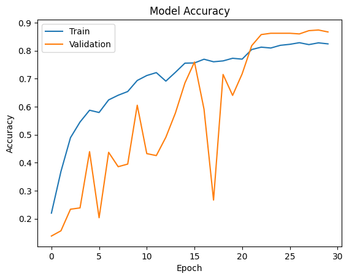

```python
plt.plot(history_2.history['accuracy'])
plt.plot(history_2.history['val_accuracy'])
plt.title('Model Accuracy')
plt.ylabel('Accuracy')
plt.xlabel('Epoch')
plt.legend(['Train', 'Validation'], loc='upper left')
plt.show()
```

```python
#model_2.evaluate(train_generator, verbose=2)
```

```python
#model_2.evaluate(x_test_normalized, y_test_encoded, verbose=2)
model_2.evaluate(test_generator, verbose=2)
```

```
8/8 - 0s - loss: 0.4401 - accuracy: 0.8653 - 270ms/epoch - 34ms/step
```

```
[0.44011390209198, 0.8652631640434265]
```

- Model 2 accuracy = 86%

```python
#Making predictions on the test data
y_pred= model_2.predict(test_generator, verbose = 1)
```

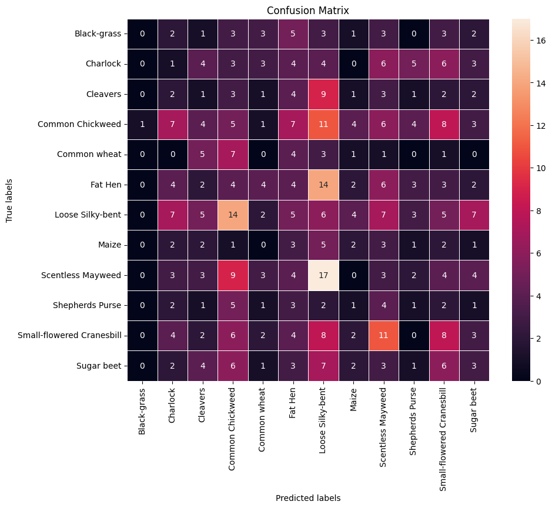

```python
# Obtaining the categorical values from y_test_encoded and y_pred
y_pred_arg=np.argmax(y_pred,axis=1)
####################
# Iterate over the test_generator to obtain the true labels
true_labels = []
for i in range(len(test_generator)):
    _, batch_true_labels = test_generator[i]
    true_labels.extend(batch_true_labels)

# Convert true_labels to a numpy array
y_test_encoded = np.array(true_labels)
#################

y_test_arg=np.argmax(y_test_encoded,axis=1)

# Plotting the Confusion Matrix using confusion matrix() function which is also predefined tensorflow module
confusion_matrix = tf.math.confusion_matrix(y_test_arg,y_pred_arg)
f, ax = plt.subplots(figsize=(10, 8))
sns.heatmap(
    confusion_matrix,
    annot=True,
    linewidths=.4,
    fmt="d",
    square=True,
    ax=ax, xticklabels=enc.classes_, yticklabels=enc.classes_
)

# Setting the labels to both the axes
ax.set_xlabel('Predicted labels');ax.set_ylabel('True labels');
ax.set_title('Confusion Matrix');
#ax.xaxis.set_ticklabels(list(enc.classes_),rotation=0)
#ax.yaxis.set_ticklabels(list(enc.classes_),rotation=90)


plt.show()
```

```python
# Plotting the classification report
from sklearn import metrics
cr=metrics.classification_report(y_test_arg,y_pred_arg)     # Complete the code to plot the classification report
print(cr)
```

```
              precision    recall  f1-score   support

           0       0.00      0.00      0.00        26
           1       0.03      0.03      0.03        39
           2       0.03      0.03      0.03        29
           3       0.08      0.08      0.08        61
           4       0.00      0.00      0.00        22
           5       0.08      0.08      0.08        48
           6       0.07      0.09      0.08        65
           7       0.10      0.09      0.10        22
           8       0.05      0.06      0.06        52
           9       0.05      0.04      0.05        23
          10       0.16      0.16      0.16        50
          11       0.10      0.08      0.09        38

    accuracy                           0.07       475
   macro avg       0.06      0.06      0.06       475
weighted avg       0.07      0.07      0.07       475
```

## Final Model

### Visualizing the prediction

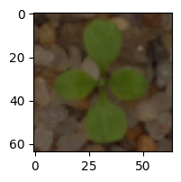

```
Predicted Label: Shepherds Purse
True Label: Shepherds Purse
```

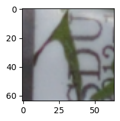

```
Predicted Label: Loose Silky-bent
True Label: Scentless Mayweed
```

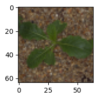

```
Predicted Label: Charlock
True Label: Charlock
```

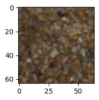

```
Predicted Label: Loose Silky-bent
True Label: Loose Silky-bent
```

```python
# Assuming you have already defined your test_generator
for _ in range(4):

  # Obtain a batch of test data and labels from the generator
  batch_images, batch_labels = next(test_generator)

  # Visualize the first image in the batch
  plt.figure(figsize=(2, 2))
  plt.imshow(batch_images[0])
  plt.show()

  # Predict the labels for the batch of images
  predictions = model_2.predict(batch_images)

  # Decode the predicted labels
  predicted_labels = enc.inverse_transform(predictions)

  # Decode the true labels
  true_labels = enc.inverse_transform(batch_labels)

  # Print the predicted and true labels for the first image in the batch
  print('Predicted Label:', predicted_labels[0])
  print('True Label:', true_labels[0])
```

## Actionable Insights and Business Recommendations

### **Findings**

- Our model 1 had 62492 trainable parameters, model 2 had 1172172 trainable parameters.
- Model 2 is the better one with more accuracy. The model 2 has converged faster after 20 epochs.
- A good level of improvement seen in loss and accuracy by using data augmentation and measures for overfitting/underfitting. Data Augmentation, Batch Normalization and the Dropout Layers.
- The data is highly imbalanced and we require more diverse samples for each of the plants, esp. those that are under represented

## Conclusion

```python
#!jupyter nbcovert --to html 'Final_CV_Project_AbrahamThomas_Full_Code_Notebook.ipynb'
```